# in situ PCR pilot studies (v4)

## Generally

- gauging efficiency of known number of nuclei and in situ PCR against a panel of reference genes
- reference genes with order-of-magnitude copy differences ==> "standard curve"

[output not shown]

## standard curves in qPCR

- a 100% efficient PCR reaction doubles in DNA quantity every cycle
- ~3 cycle difference = 1 order of magnitude difference in DNA amount

# v4 controls, curves by sample

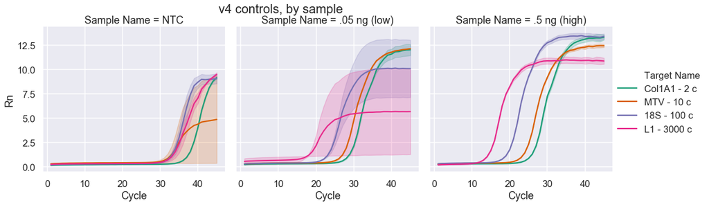

```python
g.fig
```

- The .05 ng L1 discrepancy (compared to .5) is due to one of the replicates failing entirely -- I think it's likely I didn't add template. The successful curve follows the top line, and would be similar in shape to L1 x.5 ng.

# v4 controls, curves by target

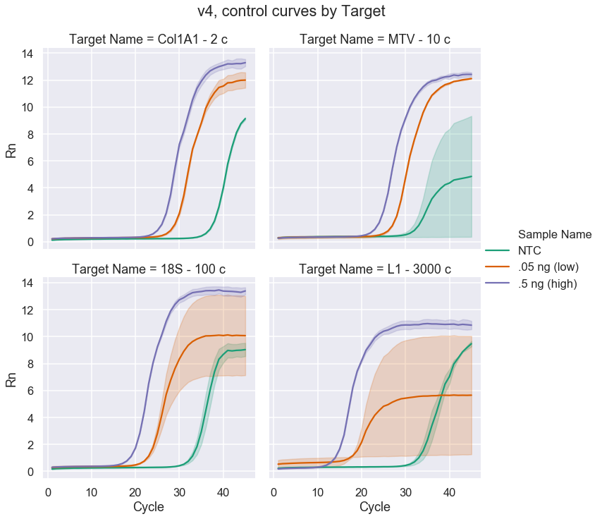

```python
g.fig
```

- same L1 discrepancy as previously, otherwise things look about normal.
- average cQ difference in subslide

```python
grp = controlResults.groupby(['Target Name', 'SampleName'])['Ct_clean'].agg(['mean', stats.gstd]).dropna().sort_values(['Target Name', 'SampleName'])
grp['diff_mean_Ct'] = grp['mean'].transform(lambda mean: mean.diff(periods = -1)) #show diffs between ct means. for triplicate, geom mean would be appropriate and matter, but doesn't play nicely with null values
grp.round(2) # difference of 3-4 cycles between template order of magnitude dilutions
```

| Target Name | SampleName | mean | gstd | diff_mean_Ct |
| --- | --- | --- | --- | --- |
| 18S - 100 c | NTC | 33.41 | 1.03 | 9.92 |
|  | .05 ng (low) | 23.49 | 1.03 | 3.99 |
|  | .5 ng (high) | 19.51 | 1.00 | -18.42 |
| Col1A1 - 2 c | NTC | 37.93 | 1.00 | 8.50 |
|  | .05 ng (low) | 29.43 | 1.01 | 3.00 |
|  | .5 ng (high) | 26.43 | 1.01 | -7.77 |
| L1 - 3000 c | NTC | 34.20 | 1.04 | 19.35 |
|  | .5 ng (high) | 14.85 | 1.00 | -12.23 |
| MTV - 10 c | .05 ng (low) | 27.08 | 1.00 | 3.36 |
|  | .5 ng (high) | 23.72 | 1.00 | NaN |

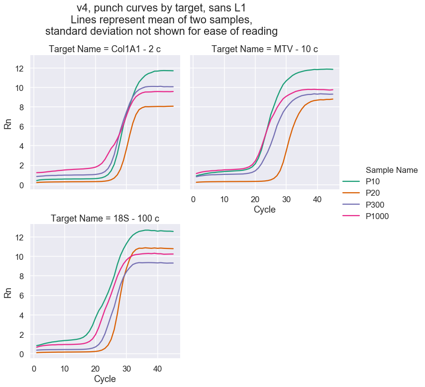

```python
# L1 dropped from analysis as it's broadly out of range of interest
g.fig
```

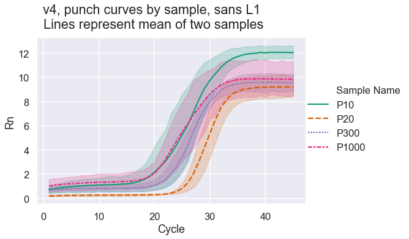

```python
g.fig
```

May not be appropriate to draw a conclusion based on this, but it appears as if P1000 (lots of nuclei) and P10 tips (smaller radius, less nuclei) amplify at similar time points, which would imply a relationship between radius size and penetration to target.